# Homework: HbA1c Control Trends — Clinics B & D, and a Simple ITS v2

## Setup

```r
library(readr)
library(dplyr)
library(lubridate)
library(qicharts2)
```

## Load the data

```r
encounters <- read_csv("data/encounters.csv")
labs <- read_csv("data/labs.csv")
lookup <- read_csv("data/provider_lookup.csv")
```

Same three files as class. This time you’re finishing Clinics B and D, which have two additional problems A and C didn’t.

## Part 1: Build the measure

### Parse dates (same as class)

```r
# TODO: reuse your mixed-date parser from class on encounter_date and
# result_date.

parse_mixed_date <- function(x) {
  d_iso <- suppressWarnings(as.Date(x, format = "%Y-%m-%d"))
  d_us  <- suppressWarnings(as.Date(x, format = "%m/%d/%Y"))
  coalesce(d_iso, d_us)
}

encounters <- encounters %>% mutate(encounter_date = parse_mixed_date(encounter_date))
labs <- labs %>% mutate(result_date = parse_mixed_date(result_date))

sum(is.na(encounters$encounter_date))
```

```
[1] 0
```

```r
sum(is.na(labs$result_date))
```

```
[1] 0
```

### Task 1: standardize the join key, then join

```r
# TODO: first, try the plain join from class:
#   encounters %>% left_join(lookup, by = "provider_id")
# and check how many rows come back with a missing clinic_id. Then look
# at a sample of the unmatched provider_id values -- what's inconsistent
# about them relative to provider_lookup.csv?
#
# TODO: create a standardized version of provider_id on BOTH tables
# (case + whitespace), then join on the standardized version. Confirm
# zero unmatched rows afterward.

encounters <- read_csv("data/encounters.csv")
encounters <- encounters %>%
  left_join(lookup, by = "provider_id")

encounters %>%
  filter(is.na(clinic_id)) %>%
  select(provider_id) %>%
  head(10)
```

```
# A tibble: 10 × 1
   provider_id
   <chr>
 1 d-dr1
 2 d-dr1
 3 d-dr3
 4 d-dr2
 5 d-dr3
 6 d-dr3
 7 b-dr2
 8 d-dr3
 9 b-dr3
10 d-dr2
```

```r
encounters <- encounters %>%
  mutate(provider_id_clean = toupper(trimws(provider_id)))

lookup <- lookup %>%
  mutate(provider_id_clean = toupper(trimws(provider_id)))

encounters <- encounters %>%
  select(-clinic_id) %>%
  left_join(
    lookup %>% select(provider_id_clean, clinic_id),
    by = "provider_id_clean"
  )

sum(is.na(encounters$clinic_id))
```

```
[1] 0
```

### Build the denominator

```r
# TODO: same logic as class,
# filter to Clinic B and Clinic D.
# set dates to month level
# reduce to unique patients per clinic per month rows
# count the number for rows

encounters <- encounters %>%
  mutate(encounter_date = parse_mixed_date(encounter_date))

labs <- labs %>%
  mutate(result_date = parse_mixed_date(result_date))

denom <- encounters %>%
  filter(clinic_id %in% c("Clinic B", "Clinic D")) %>%
  mutate(month = floor_date(encounter_date, "month")) %>%
  distinct(clinic_id, month, patient_id) %>%
  count(clinic_id, month, name = "denominator")

head(denom)
```

```
# A tibble: 6 × 3
  clinic_id month      denominator
  <chr>     <date>           <int>
1 Clinic B  2023-01-01          30
2 Clinic B  2023-02-01          41
3 Clinic B  2023-03-01          37
4 Clinic B  2023-04-01          31
5 Clinic B  2023-05-01          33
6 Clinic B  2023-06-01          40
```

### Clean the labs and handle Task 2: implausible values

```r
# TODO: filter to test_name == "HbA1c", convert result_value to numeric,
# drop non-numeric/missing entries, remove exact duplicates -- same logic as
# class.

hba1c_clean <- labs %>%
  filter(test_name == "HbA1c") %>%
  distinct(patient_id, result_date, test_name, result_value) %>%
  mutate(result_value = suppressWarnings(as.numeric(result_value))) %>%
  filter(!is.na(result_value)) %>%
  mutate(month = floor_date(result_date, "month"))
```

```r
# TODO (Task 2): before computing the numerator, add a plausible-range
# filter on the numeric value (a reasonable range for this exercise is
# roughly 4-15). Report how many rows this excludes. Also convert dates to month.
sum(hba1c_clean$result_value < 4 | hba1c_clean$result_value > 15)
```

```
[1] 18
```

```r
# This excludes 18 rows.

hba1c_clean <- hba1c_clean %>%
  filter(result_value >= 4, result_value <= 15)

sum(hba1c_clean$result_value < 4 | hba1c_clean$result_value > 15)
```

```
[1] 0
```

### Build the numerator and assemble the measure table

```r
# TODO: same join-back-to-clinic-month logic as class
# First, identify unique patient visits in a month.

patient_clinic_month <- encounters %>%
  filter(clinic_id %in% c("Clinic B", "Clinic D")) %>%
  mutate(month = floor_date(encounter_date, "month")) %>%
  distinct(clinic_id, month, patient_id)

head(patient_clinic_month)
```

```
# A tibble: 6 × 3
  clinic_id month      patient_id
  <chr>     <date>     <chr>
1 Clinic D  2023-09-01 D-P0034
2 Clinic B  2023-08-01 B-P0017
3 Clinic B  2025-04-01 B-P0062
4 Clinic D  2025-03-01 D-P0009
5 Clinic B  2025-11-01 B-P0013
6 Clinic D  2024-09-01 D-P0007
```

```r
# Finish generating a numerator - # of patients with controlled values (under 8)
# Filter to controlled lab values, join to the patient-by month file above.
# Identify unique patients per month per clinic
# Count how many patients per month had controlled lab values. This is the numerator.
#
numer <- hba1c_clean %>%
  filter(result_value < 8) %>%
  inner_join(patient_clinic_month, by = c("patient_id", "month")) %>%
  distinct(clinic_id, month, patient_id) %>%
  count(clinic_id, month, name = "numerator")

head(numer)
```

```
# A tibble: 6 × 3
  clinic_id month      numerator
  <chr>     <date>         <int>
1 Clinic B  2023-01-01        15
2 Clinic B  2023-02-01        19
3 Clinic B  2023-03-01        19
4 Clinic B  2023-04-01        16
5 Clinic B  2023-05-01        17
6 Clinic B  2023-06-01        19
```

```r
# Join numerator and denominator together
measure <- denom %>%
  left_join(numer, by = c("clinic_id", "month")) %>%
  mutate(numerator = coalesce(numerator, 0L))

head(measure)
```

```
# A tibble: 6 × 4
  clinic_id month      denominator numerator
  <chr>     <date>           <int>     <int>
1 Clinic B  2023-01-01          30        15
2 Clinic B  2023-02-01          41        19
3 Clinic B  2023-03-01          37        19
4 Clinic B  2023-04-01          31        16
5 Clinic B  2023-05-01          33        17
6 Clinic B  2023-06-01          40        19
```

## Part 2: Control charts

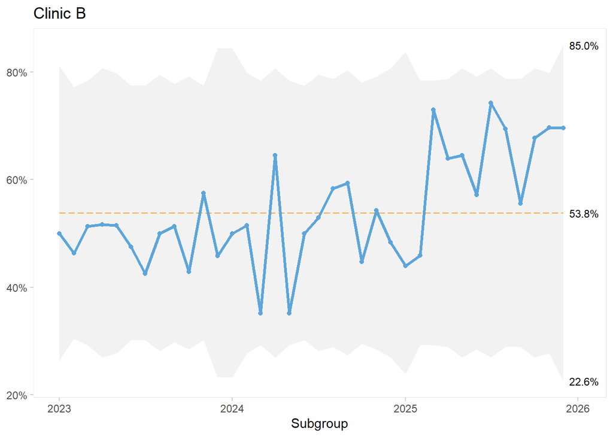

```r
# TODO: qic() with chart = "p" for Clinic B. Store the result.

q_b <- qic(
  x = month, y = numerator, n = denominator,
  data = measure %>% filter(clinic_id == "Clinic B") %>% arrange(month),
  chart = "p", title = "Clinic B"
)
q_b
```

```r
any(q_b$data$runs.signal, na.rm = TRUE)
```

```
[1] TRUE
```

*Clinic B interpretation:*

> Runs signal present. Most points are below center line from the start in 2023 to a early 2025. Then it is above the center line from early 2025 to 2026 but its still fluctuating all throughout the months. Plausible cause for the fluctuations could be a change in patient management or a significant workflow change. [3-5 sentences: signal present? sigma or runs? plausible cause? next step?]

> **One-line status:** Clinic B - runs signal present, look into changing overall workflow process

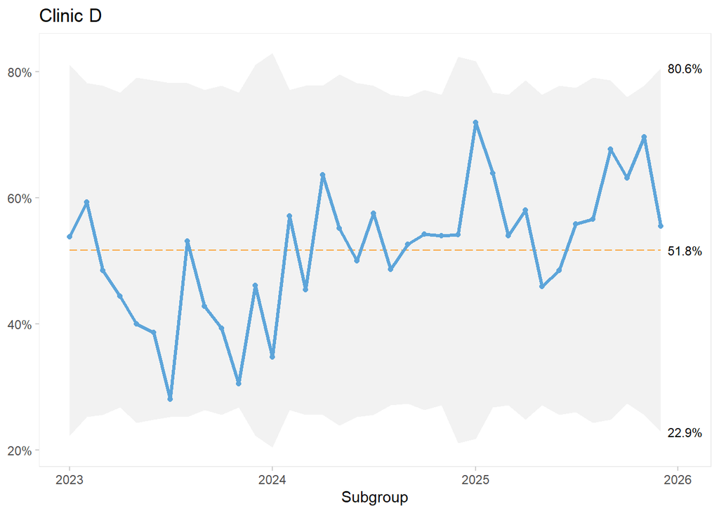

```r
# TODO: qic() with chart = "p" for Clinic D.
q_d <- qic(
  x = month, y = numerator, n = denominator,
  data = measure %>% filter(clinic_id == "Clinic D") %>% arrange(month),
  chart = "p", title = "Clinic D"
)
q_d
```

```r
any(q_d$data$runs.signal, na.rm = TRUE)
```

```
[1] TRUE
```

*Clinic D interpretation:*

> Runs signal present. Most points are above center line from the start in 2023 to a little after 2023. Then it is below the center line until a little after 2024. From then to 2026, most points are above the center line, but it is still fluctuating throughout the months. Plausible cause for the fluctuations could be a change in patient management or a significant workflow change.

> **One-line status:** Clinic D - runs signal present, look into changing overall workflow process

## Part 3: A simple interrupted time series (Clinic B)

```r
# TODO: build a data frame for Clinic B with:
#   - rate = numerator / denominator
#   - t = a simple 1, 2, 3, ... month counter
#   - post = 0/1 indicator for month >= 2025-03-01
#   - t_post = post * (a counter that starts at 1 on the intervention
#     month and counts up from there, 0 before it)
sits_b <- measure %>%
  filter(clinic_id == "Clinic B") %>%
  arrange(month) %>%
  mutate(
    rate = numerator / denominator,
    t = 1:n(),
    post = ifelse(month >= as.Date("2025-03-01"), 1, 0),
    t_post = ifelse(post == 1, t - which(month == as.Date("2025-03-01")) + 1, 0)
  )

head(sits_b)
```

```
# A tibble: 6 × 8
  clinic_id month      denominator numerator  rate     t  post t_post
  <chr>     <date>           <int>     <int> <dbl> <int> <dbl>  <dbl>
1 Clinic B  2023-01-01          30        15 0.5       1     0      0
2 Clinic B  2023-02-01          41        19 0.463     2     0      0
3 Clinic B  2023-03-01          37        19 0.514     3     0      0
4 Clinic B  2023-04-01          31        16 0.516     4     0      0
5 Clinic B  2023-05-01          33        17 0.515     5     0      0
6 Clinic B  2023-06-01          40        19 0.475     6     0      0
```

```r
# TODO: fit lm(rate ~ t + post, data = ...) and look at
# summary(). Extract/interpret the post and t_post coefficients.
sits_model <- lm(rate ~ t + post + t_post, data = sits_b)

summary(sits_model)
```

```
Call:
lm(formula = rate ~ t + post + t_post, data = sits_b)

Residuals:
      Min        1Q    Median        3Q       Max
-0.142834 -0.035194  0.008948  0.028852  0.151227

Coefficients:
             Estimate Std. Error t value Pr(>|t|)
(Intercept) 0.4899238  0.0273379  17.921  < 2e-16 ***
t           0.0002507  0.0017702   0.142  0.88828
post        0.1627426  0.0529581   3.073  0.00431 **
t_post      0.0007557  0.0076605   0.099  0.92203
---
Signif. codes:  0 '***' 0.001 '**' 0.01 '*' 0.05 '.' 0.1 ' ' 1

Residual standard error: 0.0677 on 32 degrees of freedom
Multiple R-squared:  0.5915,    Adjusted R-squared:  0.5532
F-statistic: 15.45 on 3 and 32 DF,  p-value: 2.176e-06
```

*Interpretation:*

> [What does the `post` coefficient mean, and is it significant? What does `t_post` mean, and is it significant? Does this agree with what the control chart’s signal already told you? Explain, in your own words, what each method is actually testing and why they might (or might not) agree.] The post coefficient is 0.163 and is significant because p = 0.004. This means that the HbA1c control rate increased after March 2025. The t_post coefficient is 0.001 and is not significant because p = 0.922. This means that there was no significant change in the slope. This matches the control chart because the p chart showed a shift from mostly below the center line to mostly above it after 2025.